# Antelope Project Analysis

Andrea Stocco

October 31, 2019

# Analyze the data

```r
process_raw = F
if (process_raw) {
  for (sub in dir(grep("A[1-9]", dir()))) {
    setwd(sub)
    analyze.logfile(sub, "closed")
    setwd("..")
  }
}
```

# Demographics and Behavioral Data

First, let’s load the data and transform it into a Wide format table

```r
behav <- read_tsv("../../behav_data.txt", col_types=cols())

behav$material[behav$material=="Swahili"] <- "Vocabulary"
behav$material[behav$material=="US Maps"] <- "Maps"

behav <- behav %>% rename(Gender = gender, Age = age)

wbehav <- behav %>% pivot_wider(values_from = alpha,
                                id_cols = c(Subject, Gender, Age),
                                names_from = material)
```

At this point, we can look at the participant demographocs

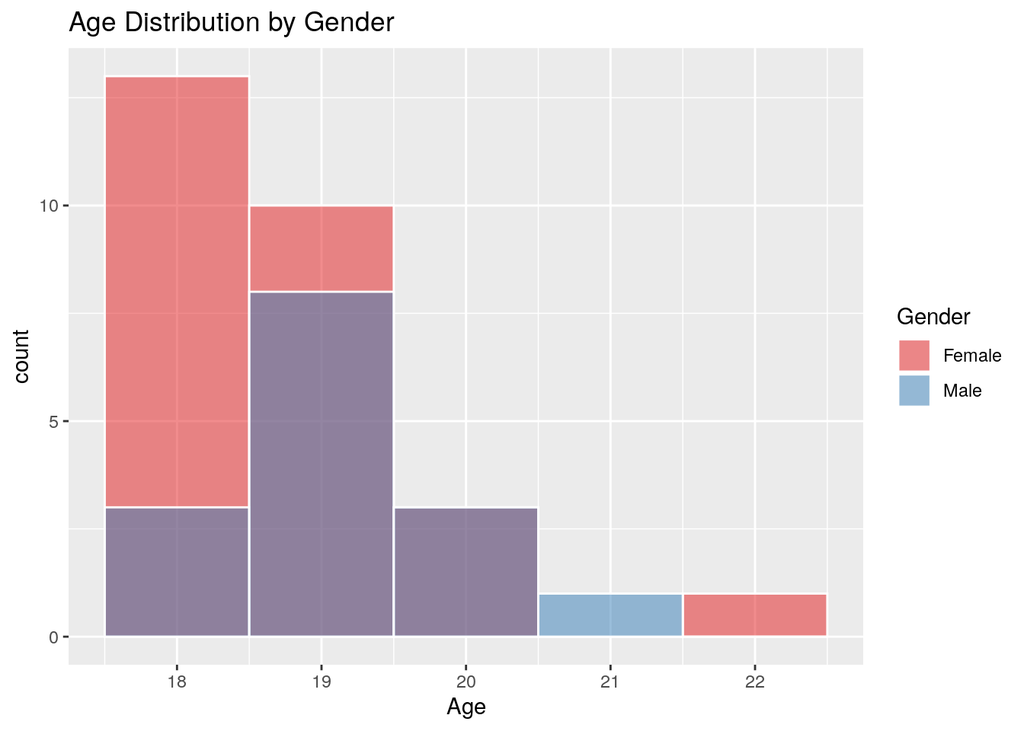

```r
ggplot(data=wbehav, aes(x=Age, col=Gender)) +
  geom_histogram(aes(col="white", fill=Gender), colour="white", alpha=0.5, position="identity", binwidth = 1) +
  #geom_density(aes(fill=Gender), colour="black", position="dodge", bw=1,  alpha=0.5) +
  scale_color_brewer(palette = "Set1") +
  scale_fill_brewer(palette = "Set1") +
  ggtitle("Age Distribution by Gender")
```

```r
  #geom_vline(aes(xintercept=grp.mean), linetype="dashed") +
  theme_pander()
```

[output not shown]

[output cut: 129 more lines]

[output not shown]

## Values of Alpha for the two tasks

We can now examine the distribution and correlation of Alpha values for Vocab and Maps:

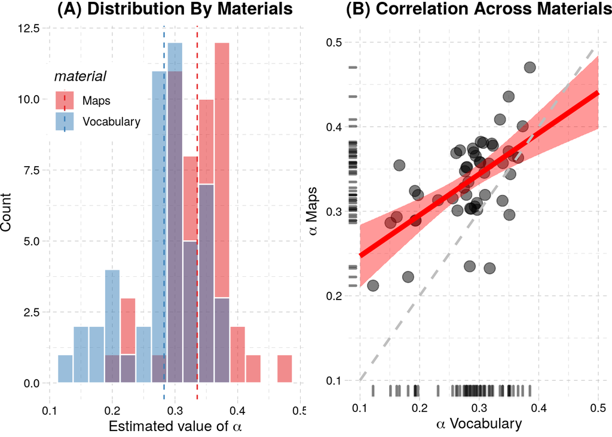

```r
mu <- behav %>% group_by(material) %>% summarize(alpha=mean(alpha))

p1 <- ggplot(behav, aes(x=alpha, fill=material)) +
  geom_histogram(col="white", binwidth = 0.025, alpha=0.5, position="identity") +
  #geom_density(aes(fill=material), colour="white", position="dodge", alpha=0.5, bw=0.025) +
  scale_color_brewer(palette = "Set1") +
  scale_fill_brewer(palette = "Set1") +
#  geom_vline(aes(fun.data=mean_se, xintercept=material), linetype="dashed") +
  geom_vline(data=mu, aes(xintercept=alpha, color=material),
             linetype="dashed") +
  xlab(expression(paste("Estimated value of ", alpha))) +
  theme_pander() +
  ylab("Count") +
  ggtitle("(A) Distribution By Materials") +
  theme(legend.position = c(0.2, 0.8)) +
  theme(plot.title = element_text(hjust = 0.5))

p2 <- ggplot(wbehav, aes(x=Vocabulary, y=Maps)) +
  geom_point(size=4, alpha=0.5, col="black") + #col=K[7]) +
  geom_smooth(method = "lm", formula = y ~ x, col="red", fill="red", fullrange = T, lwd=2) +
  theme_pander() +
  #stat_density_2d(col="red", alpha=0.2) +
  scale_x_continuous() +
  scale_y_continuous() +
  ggtitle("(B) Correlation Across Materials") +
  xlab(expression(paste(alpha, " Vocabulary"))) +
  ylab(expression(paste(alpha, " Maps"))) +
  geom_rug(col="black", lwd=1, alpha=.5) +
  annotate("segment", x=0.1, y=0.1, xend=0.5,
           yend=0.5, col="grey", lwd=1, lty=2) +
  theme(plot.title = element_text(hjust = 0.5))


grid.arrange(p1, p2, ncol=2)
```

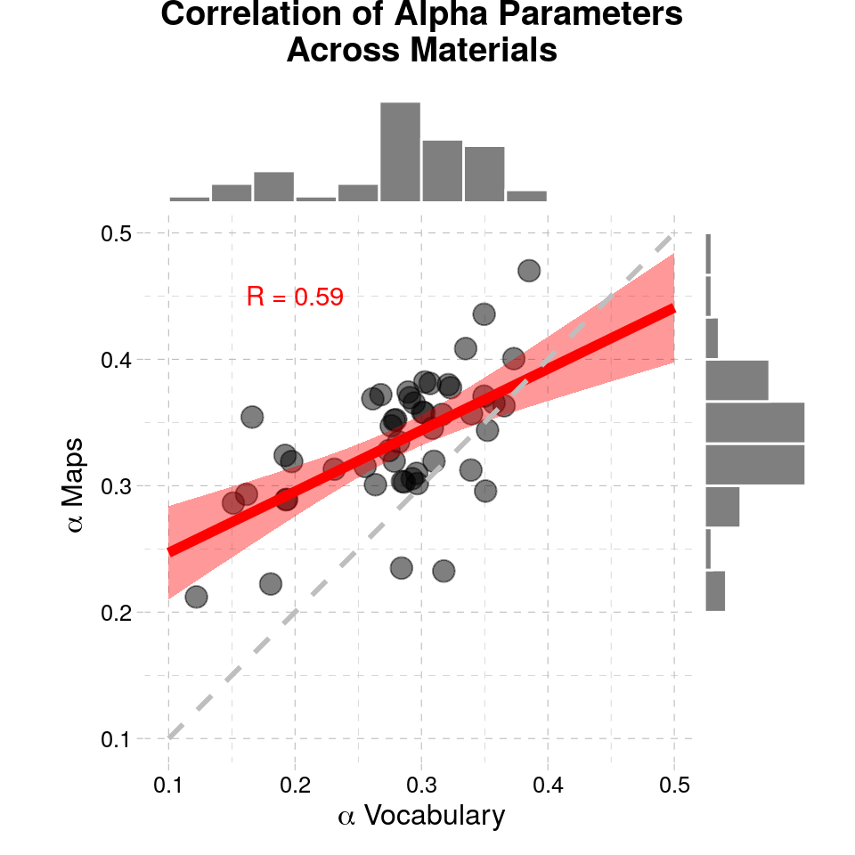

```r
p3 <- ggplot(wbehav, aes(x=Vocabulary, y=Maps)) +
  geom_point(size=4, alpha=0.5, col="black") + #col=K[7]) +
  geom_smooth(method = "lm", formula = y ~ x, col="red", fill="red", fullrange = T, lwd=2) +
  theme_pander() +
  scale_x_continuous() +
  scale_y_continuous() +
  coord_fixed() +
  ggtitle("Correlation of Alpha Parameters\nAcross Materials") +
  xlab(expression(paste(alpha, " Vocabulary"))) +
  ylab(expression(paste(alpha, " Maps"))) +
  annotate("segment", x=0.1, y=0.1, xend=0.5,
           yend=0.5, col="grey", lwd=1, lty=2) +
  annotate("text", label = paste("R =", round(cor(wbehav$Vocabulary,
                                                  wbehav$Maps),
                                              2)),
                                 x=0.2, y=0.45, col="red") +

  theme(plot.title = element_text(hjust = 0.5))

ggMarginal(p3, col="white", fill="black", alpha=0.5,
           type="hist", bins=13)
```

And here is a summary of the data:

```r
summary(wbehav) %>%
  kable(digits = 3) %>%
  kable_styling(bootstrap_options = c("striped", "hover"))
```

Subject

[output not shown]

[output not shown]

Vocabulary

[output not shown]

Length:50

Length:50

Min. :18.00

Min. :0.1219

Min. :0.2120

Class :character

Class :character

1st Qu.:18.00

1st Qu.:0.2647

1st Qu.:0.3039

Mode :character

Mode :character

Median :19.00

Median :0.2917

Median :0.3447

NA

NA

Mean :18.88

Mean :0.2825

Mean :0.3355

NA

NA

3rd Qu.:19.00

3rd Qu.:0.3203

3rd Qu.:0.3680

NA

NA

Max. :22.00

Max. :0.3852

Max. :0.4701

NA

NA

NA’s :8

NA

NA

# Load the spectra

```r
spectra <- NULL
for (sub in dir()[grep("A[1-9]", dir())]) {
  table <- read_tsv(paste(sub, "/", sub, "_closed_spectra.txt", sep=""),
                    col_types = cols())
  if (is.null(spectra)) {
    spectra <- table
  } else {
    spectra <- spectra %>% bind_rows(table)
  }
}
```

# EEG Data Analysis

Here we begin looking at the EEG data analysis

## Average spectrum

First, let’s examine the spectrograms for each channel to make sure it looks normal and the IAF (individual alpha frequency) is reasonable, i.e., the same for each channel and roughly in the middle of the band definition

```r
lspectra <- pivot_longer(spectra, cols=names(spectra)[3:130], names_to="Freq")

lspectra <- lspectra %>% rename(Power = value)
#lspectra <- lspectra %>% mutate(Power = exp(Power))
lspectra$Frequency <- as.numeric(substr(lspectra$Freq, 0, str_length(lspectra$Freq) -2))
lspectra <- lspectra %>% add_column(Band="Delta", BandMin=0, BandMax=4)
lspectra$Band[lspectra$Frequency <= 40] <- "Gamma"
lspectra$Band[lspectra$Frequency < 30] <- "High Beta"
lspectra$Band[lspectra$Frequency < 18] <- "Upper Beta"
lspectra$Band[lspectra$Frequency < 15] <- "Low Beta"
lspectra$Band[lspectra$Frequency < 13] <- "Alpha"
lspectra$Band[lspectra$Frequency < 8] <- "Theta"
lspectra$Band[lspectra$Frequency < 4] <- "Delta"

lspectra$BandMin[lspectra$Frequency <= 40] <- 30
lspectra$BandMin[lspectra$Frequency < 30] <- 18
lspectra$BandMin[lspectra$Frequency < 18] <- 13 #15
lspectra$BandMin[lspectra$Frequency < 15] <- 13
lspectra$BandMin[lspectra$Frequency < 13] <- 8
lspectra$BandMin[lspectra$Frequency < 8] <- 4
lspectra$BandMin[lspectra$Frequency < 4] <- 0

lspectra$BandMax[lspectra$Frequency <= 40] <- 40
lspectra$BandMax[lspectra$Frequency < 30] <- 30
lspectra$BandMax[lspectra$Frequency < 18] <- 18
lspectra$BandMax[lspectra$Frequency < 15] <- 15
lspectra$BandMax[lspectra$Frequency < 13] <- 13
lspectra$BandMax[lspectra$Frequency < 8] <- 8
lspectra$BandMax[lspectra$Frequency < 4] <- 4

lspectra$Band <- factor(lspectra$Band,
                        levels = c("Delta", "Theta", "Alpha",
                                   "Low Beta", "Upper Beta",
                                   "High Beta", "Gamma"))
```

Now, we remove the three participants for which we have poor quality data

```r
lspectra <- lspectra %>%
  filter(Subject %in% behav$Subject)
```

Now, we can visualize the power spectra

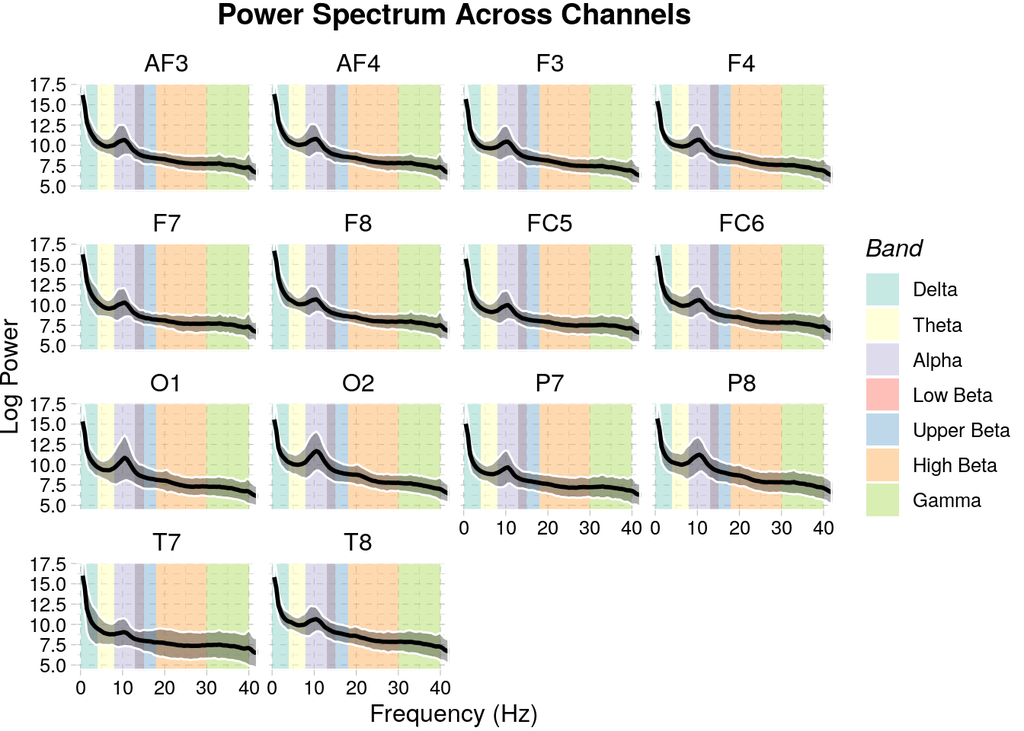

```r
gd <- lspectra %>%
        group_by(Band) %>%
        summarise(
          Min = mean(BandMin),
          Max = mean(BandMax),
          Power =mean(Power),
          Frequency = mean(BandMin)
          #Channel=
        )

ggplot(data=lspectra, aes(x=Frequency, y=Power, Channel)) +
  geom_rect(data = gd, aes(xmin=Min, xmax=Max, fill=Band),  ymin=0, ymax=Inf, colour=NA, alpha=0.5) +
  stat_summary(#aes(fill=Channel),
               fun.data=mean_sdl,
               geom="ribbon", colour="white", alpha=0.4) +
  stat_summary(fun.y=mean, geom="line", lwd=1) +
  facet_wrap(~ Channel, ncol=4) +
  scale_alpha_manual(values = seq(0.1, 0.9, 0.1)) +
  ggtitle("Power Spectrum Across Channels") +
  ylab("Log Power") +
  xlab("Frequency (Hz)") +
  theme_pander() +
  coord_cartesian(xlim=c(1,40), ylim=c(5, 17)) + #ylim=c(5,17)) +
  scale_fill_brewer(palette = "Set3") +
  theme(plot.title = element_text(hjust = 0.5))
```

Now, let’s create a mean spectrogram with annotations that mark the frequency bands

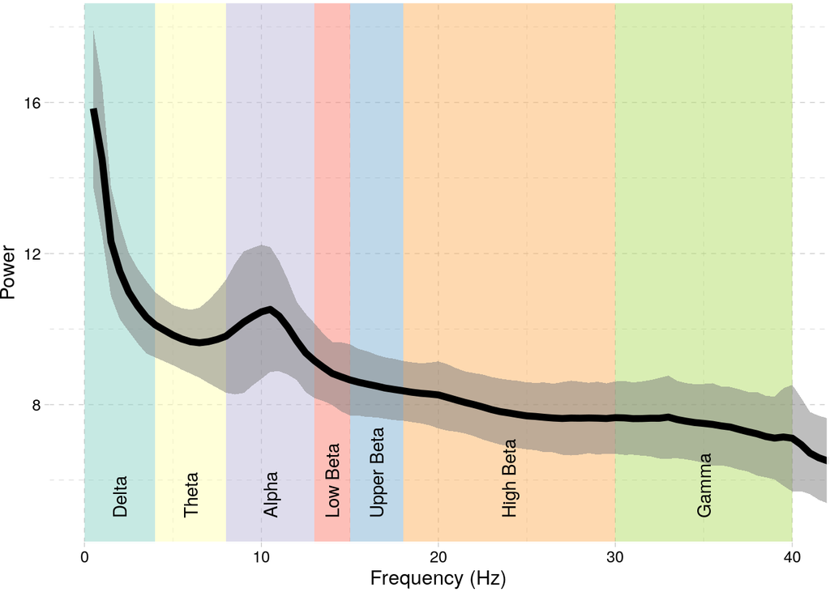

```r
K = brewer.pal(7, "Set3")

alspectra <- aggregate(lspectra[c("Power")],
                       list(Subject=lspectra$Subject,
                            Frequency=lspectra$Frequency,
                            Band=lspectra$Band),
                       mean)

ggplot(data=alspectra, aes(x=Frequency, y=Power, col=Power)) +
  annotate("rect", xmin = 0, xmax = 4, ymin = 0, ymax = Inf,
           alpha = 0.5, fill=K[1]) +
  annotate("rect", xmin = 4, xmax = 8, ymin = 0, ymax = Inf,
           alpha = 0.5, fill=K[2]) +
  annotate("rect", xmin = 8, xmax = 13, ymin = 0, ymax = Inf,
           alpha = 0.5, fill=K[3]) +
  annotate("rect", xmin = 13, xmax = 15, ymin = 0, ymax = Inf,
           alpha = 0.5, fill=K[4]) +
  annotate("rect", xmin = 15, xmax = 18, ymin = 0, ymax = Inf,
           alpha = 0.5, fill = K[5]) +
  annotate("rect", xmin = 18, xmax = 30, ymin = 0, ymax = Inf,
           alpha = 0.5, fill=K[6]) +
  annotate("rect", xmin = 30, xmax = 40, ymin = 0, ymax = Inf,
           alpha = 0.5, fill=K[7]) +
  stat_summary(fun.data=mean_sdl, geom="ribbon",
               alpha=0.5, fill="grey50") +
  stat_summary(fun.y=mean, geom="line", lwd=2) +
  coord_cartesian(xlim=c(0,40), ylim=c(5,18)) +
  xlab("Frequency (Hz)") +
  theme_pander() +
  annotate("text", x=2, y=5, label="Delta", angle=90, hjust=0) +
  annotate("text", x=6, y=5, label="Theta", angle=90, hjust=0) +
  annotate("text", x=10.5, y=5, label="Alpha", angle=90, hjust=0) +
  annotate("text", x=14, y=5, label="Low Beta", angle=90, hjust=0) +
  annotate("text", x=16.5, y=5, label="Upper Beta", angle=90, hjust=0) +
  annotate("text", x=24, y=5, label="High Beta", angle=90, hjust=0) +
  annotate("text", x=35, y=5, label="Gamma", angle=90, hjust=0)
```

# Correlations with Learning Rate

First, we calculate the mean power for every band and channel, and remove participants not inclided

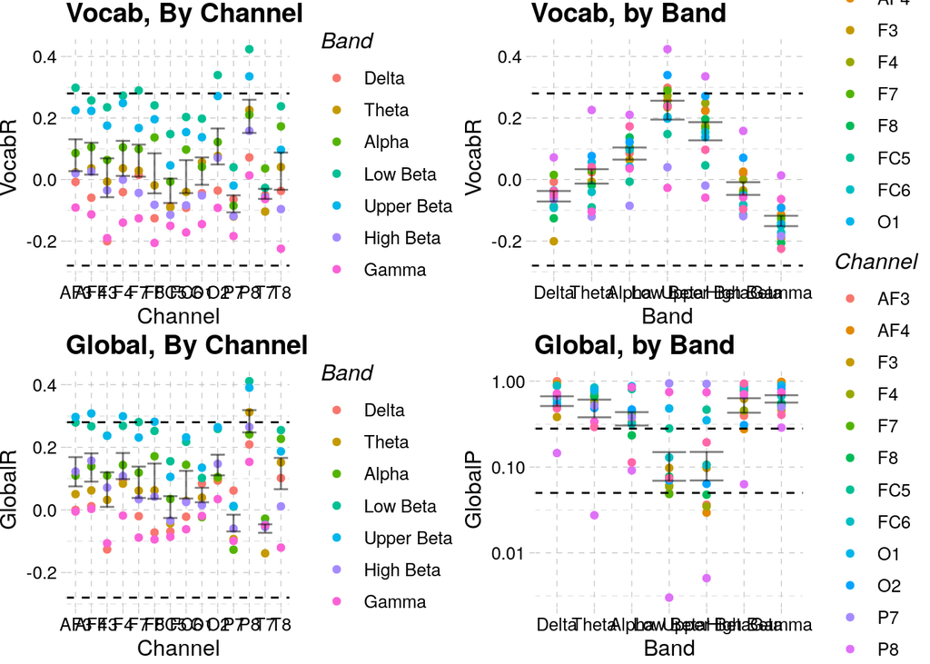

```r
wbehav <- wbehav %>%
  mutate(GlobalAlpha=(Vocabulary + Maps)/2)

Adata <- lspectra %>% group_by(Subject, Channel, Band) %>% summarize(Power=mean(Power))

Cdata <- group_by(Adata, Channel, Band) %>%
  summarize(VocabR = cor(Power, wbehav$Vocabulary),
            MapsR = cor(Power, wbehav$Maps),
            GlobalR = cor(Power, wbehav$GlobalAlpha),
            VocabP = cor.test(Power, wbehav$Vocabulary)$p.value,
            MapsP = cor.test(Power, wbehav$Maps)$p.value,
            GlobalP = cor.test(Power, wbehav$GlobalAlpha)$p.value)

p1 <-ggplot(Cdata, aes(x=Channel, y=VocabR, col=Band)) +
  geom_point() +
  stat_summary(fun.data = "mean_se", col="black", alpha=0.5, geom = "errorbar") +
  ggtitle("Vocab, By Channel") +
  annotate("segment", x=-Inf, xend=Inf, y=0.28, yend = 0.28, lty=2) +
  annotate("segment", x=-Inf, xend=Inf, y=-0.28, yend = -0.28, lty=2) +

  theme_pander()

p2 <- ggplot(Cdata, aes(x=Band, y=VocabR, col=Channel)) +
  geom_point() +
  stat_summary(fun.data = "mean_se", col="black", alpha=0.5, geom = "errorbar") +
  ggtitle("Vocab, by Band") +
  annotate("segment", x=-Inf, xend=Inf, y=0.28, yend = 0.28, lty=2) +
  annotate("segment", x=-Inf, xend=Inf, y=-0.28, yend = -0.28, lty=2) +
  theme_pander()


p3 <-ggplot(Cdata, aes(x=Channel, y=GlobalR, col=Band)) +
  geom_point() +
  stat_summary(fun.data = "mean_se", col="black", alpha=0.5, geom = "errorbar") +
  ggtitle("Global, By Channel") +
  annotate("segment", x=-Inf, xend=Inf, y=0.28, yend = 0.28, lty=2) +
  annotate("segment", x=-Inf, xend=Inf, y=-0.28, yend = -0.28, lty=2) +

  theme_pander()

p4 <- ggplot(Cdata, aes(x=Band, y=GlobalP, col=Channel)) +
  geom_point() +
  stat_summary(fun.data = "mean_se", col="black", alpha=0.5, geom = "errorbar") +
  ggtitle("Global, by Band") +
  annotate("segment", x=-Inf, xend=Inf, y=0.28, yend = 0.28, lty=2) +
  annotate("segment", x=-Inf, xend=Inf, y=-0.28, yend = -0.28, lty=2) +
  annotate("segment", x=-Inf, xend=Inf, y=0.05, yend = 0.05, lty=2) +
  scale_y_log10() +
  theme_pander()
grid.arrange(p1, p2, p3, p4, ncol=2)
```